# Fish Recruitment Analysis

#### 4.1.4.2 2 Fitting

2.1 Priors only

```r
priors <- prior(normal(2, 1), class = "Intercept") +
  prior(normal(0, 5), class = "b") +
  prior(cauchy(0, 2), class = "sd") +
  prior(uniform(-1, 1), class = "ar") +
  prior(cauchy(0, 2), class = "sderr")

abnd.brm1 <- brm(abnd.form,
  data = fish.sp.abnd,
  prior = priors,
  sample_prior = "only",
  iter = 5000, warmup = 1000,
  chains = 3, cores = 3,
  thin = 5
)
save(abnd.brm1, file = paste0(DATA_PATH, "modelled/abnd.brmprior1.RData"))
```

The above code model did fit, but I had trouble with using ggpredict on it (see below)

```r
load(file = paste0(DATA_PATH, "modelled/abnd.brmprior1.RData"))

abnd.brm1 %>% ggpredict(~Treatment) %>% plot(add.data = TRUE)
```

```
Error in h(simpleError(msg, call)): error in evaluating the argument 'x' in selecting a method for function 'plot': The following variables can neither be found in 'data' nor in 'data2':
'Date'
```

```r
abnd.brm1$data$Date %>% class()
```

```
[1] "factor"
```

```r
abnd.brm1$data$Date <- factor(abnd.brm1$data$Date)
abnd.brm1$data$Date %>% class()
```

```
[1] "factor"
```

```r
##this did not change that ggpredict didn't work

fish.sp.abnd$Date %>% class()
```

```
[1] "Date"
```

```r
fish.sp.abnd <- fish.sp.abnd %>%
  mutate(Date = factor(Date))
##this, then rerunning the model, did not change that ggpredict didn't work either
##ggpredict still works for murray's examples (e.g. bglmm_example5, owls.brm2)
##so probably not an update of ggpredict() issue
## more likely something to do with the ar() term
```

Changing the class of ‘Date’ and refitting the model did not fix the issue

2.2 Fit alternative model (no ar term)

```r
abnd.form <- bf(abundance ~ Treatment + (1 | plotID),
  family = poisson(link = "log")
)

priors <- prior(normal(2, 1), class = "Intercept") +
  prior(normal(0, 5), class = "b") +
  prior(cauchy(0, 2), class = "sd")

abnd.brm2.prior <- brm(abnd.form,
  data = fish.sp.abnd,
  prior = priors,
  sample_prior = "only",
  iter = 5000, warmup = 1000,
  chains = 3, cores = 3,
  thin = 5
)

save(abnd.brm2.prior, file = paste0(DATA_PATH, "modelled/abnd.brmprior2.RData"))
```

The model fit, however and ggpredict worked for this model and allowed refinement of the priors for the b’s

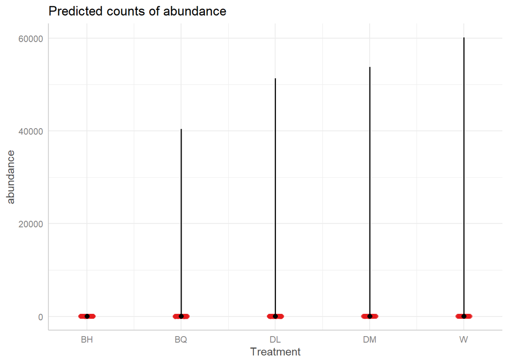

```r
load(file = paste0(DATA_PATH, "modelled/abnd.brmprior2.RData"))

abnd.brm2.prior %>%
  ggpredict(~Treatment) %>%
  plot(add.data = TRUE)
```

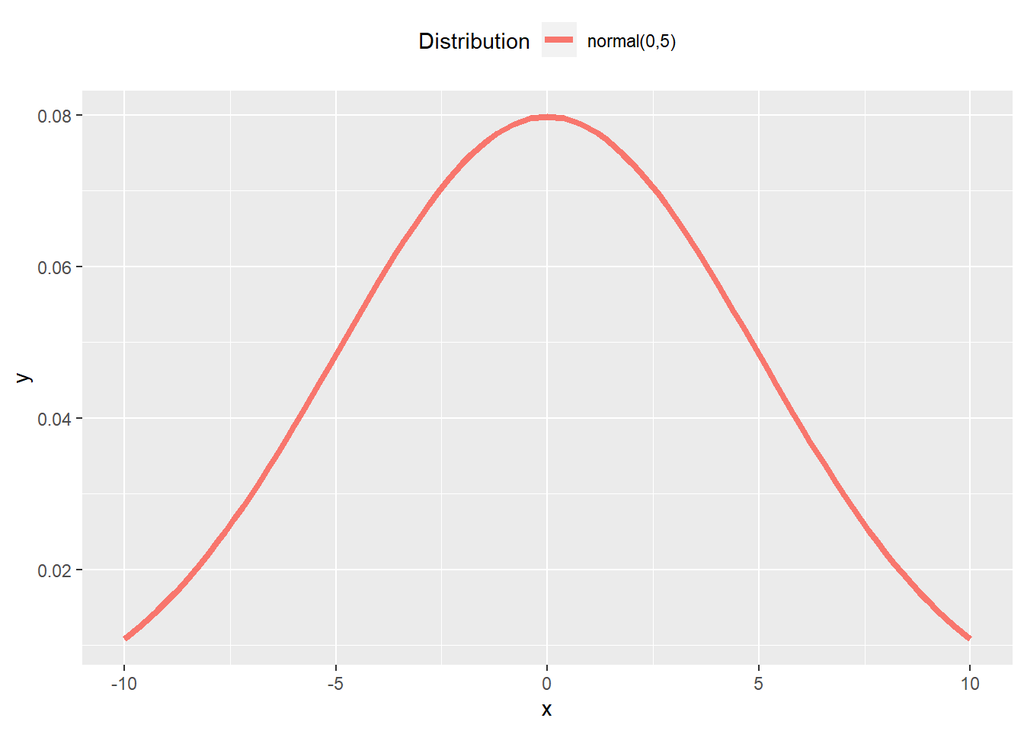

```r
standist::visualize("normal(0,5)")
```

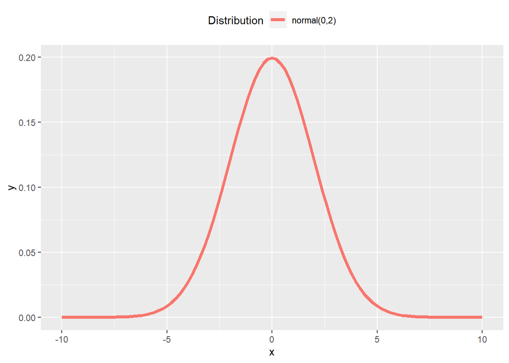

```r
standist::visualize("normal(0,2)")
```

```r
exp(c(2, 3, 5, 10))
```

```
[1]     7.389056    20.085537   148.413159 22026.465795
```

a normal(0,2) was deemed probably more appropriate for b

2.3 Fit model, sampling from data and from priors

```r
abnd.form <- bf(
  abundance ~ Treatment
    + (1 | plotID),
  autocor = ~ ar(time = Date, gr = plotID, p = 1),
  family = poisson(link = "log")
)

priors <- prior(normal(2, 1), class = "Intercept") +
  prior(normal(0, 2), class = "b") +
  prior(cauchy(0, 2), class = "sd") +
  prior(uniform(-1, 1), class = "ar") +
  prior(cauchy(0, 2), class = "sderr")

abnd.brm1a <- update(abnd.brm1, sample_prior = "yes")
save(abnd.brm1a, file = paste0(DATA_PATH, "modelled/abnd.brm1.RData"))

priors <- prior(normal(2, 1), class = "Intercept") +
  prior(normal(0, 2), class = "b") +
  prior(cauchy(0, 1), class = "sd") +
  prior(uniform(0, 1), class = "ar", lb = 0, ub = 1) +
  prior(cauchy(0, 1), class = "sderr")

abnd.brm1b <- update(abnd.brm1a, prior = priors, seed = 123, refresh = 0)

abnd.brm1b %>% prior_summary()

abnd.brm1b %>%
  hack_size.brmsfit() %>%
  saveRDS(file = paste0(DATA_PATH, "modelled/abnd.brm1b.rds"))
```

The eventual priors and model “abnd.brm1b” was chosen because: ar: there was no reason to expect a negative autocorrelation could occur, and reducing the prior slightly improved std.errors and ess’s sd and sderr: reducing the priors reduced the magnitude of difference between the posterior and prior. minimal effect on results, possibly more ess and smaller CI

The model fit, ggpredict had trouble, and there seems to be an error estimate for every data point (err[1]…err[450]). Compare with:

b_Intercept, b_TreatmentBQ, b_TreatmentDL, b_TreatmentDM, b_TreatmentW, sd_plotID__Intercept, r_plotID[BH1,Intercept], r_plotID[BH2,Intercept], r_plotID[BH3,Intercept], r_plotID[BH4,Intercept], r_plotID[BH5,Intercept], r_plotID[BQ1,Intercept], r_plotID[BQ2,Intercept], r_plotID[BQ3,Intercept], r_plotID[BQ4,Intercept], r_plotID[BQ5,Intercept], r_plotID[DL1,Intercept], r_plotID[DL2,Intercept], r_plotID[DL3,Intercept], r_plotID[DL4,Intercept], r_plotID[DL5,Intercept], r_plotID[DM1,Intercept], r_plotID[DM2,Intercept], r_plotID[DM3,Intercept], r_plotID[DM4,Intercept], r_plotID[DM5,Intercept], r_plotID[W1,Intercept], r_plotID[W2,Intercept], r_plotID[W3,Intercept], r_plotID[W4,Intercept], r_plotID[W5,Intercept], lprior, lp**, accept_stat**, stepsize**, treedepth**, n_leapfrog**, divergent**, energy__

(the variables of the model without the ar term)

#### 4.1.4.3 3 Prior Checks

Prior for the intercept and treatment seem appropriate. sd and sderr could potentially shrink if further diagnostics reveal problems

#### 4.1.4.4 4 MCMC diagnostics

```r
abnd.brm1b <- readRDS(file = paste0(DATA_PATH, "modelled/abnd.brm1b.rds"))
pars <- abnd.brm1b %>% get_variables()

wch <- str_extract(pars, #get the names of the variables
                   '^b_.*|^sd.*|^ar.*') %>% #that start with b, sd or ar
  na.omit # omit the rest, resulting in an object of class 'omit'
wch
```

[output not shown]

[output cut: 19 more lines]

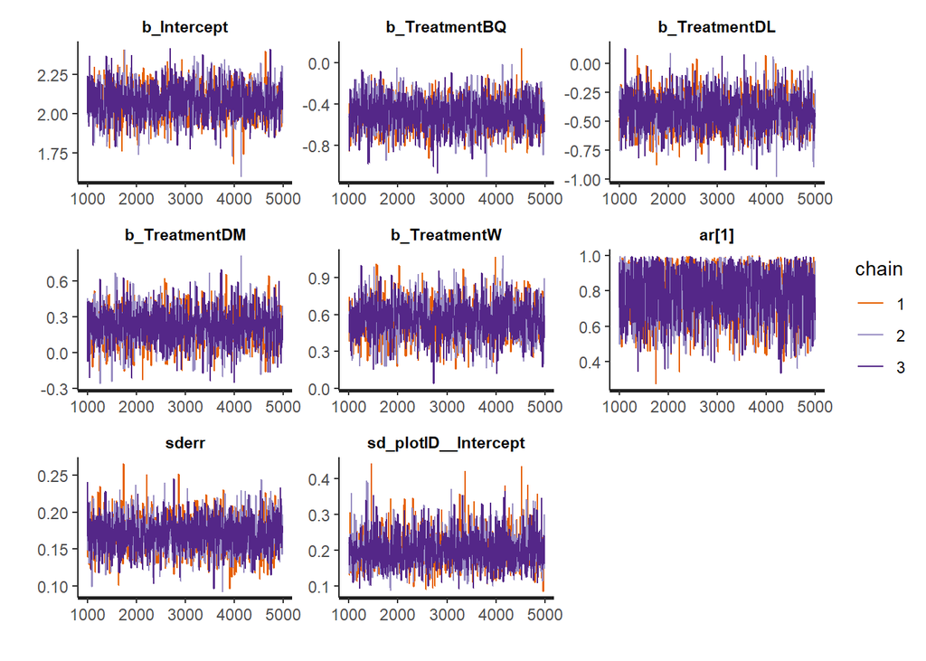

```r
##Trace Plots
stan_trace(abnd.brm1b$fit, pars = wch)
```

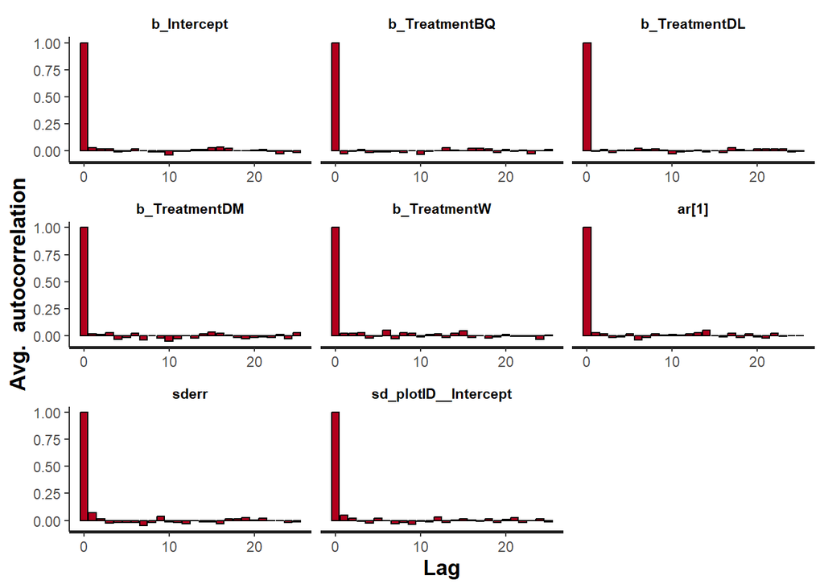

```r
##Autocorrelation factor
stan_ac(abnd.brm1b$fit, pars = wch)
```

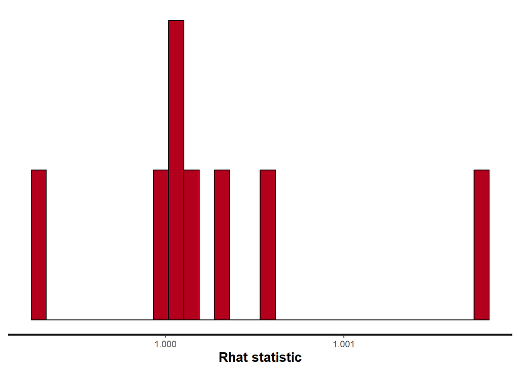

```r
##rhat - Scale reduction factor
stan_rhat(abnd.brm1b$fit, pars = wch)
```

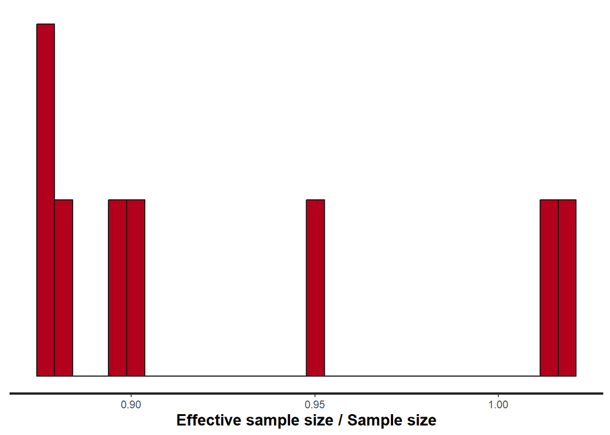

```r
##ESS (effective sample size)
stan_ess(abnd.brm1b$fit, pars = wch)
```

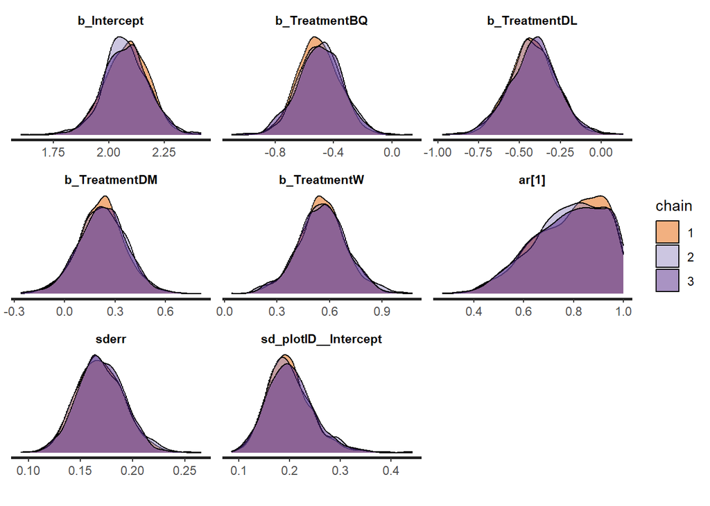

```r
##Density plot
stan_dens(abnd.brm1b$fit, pars = wch, separate_chains = TRUE)
```

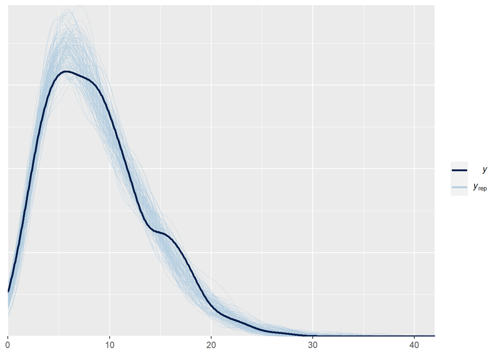

```r
##Density overlay
abnd.brm1b%>% pp_check(type = 'dens_overlay', ndraws = 100)
```

Chains are well mixed, autocorrelation factors are low, rhats are around 1 and less than 1.05, effective sample sizes for the posteriors are all close to 1 and well above 0.5 and posterior distributions of the separate chains resemble one another

“All chains were well mixed and converged (all Rhat values <1.05)”

#### 4.1.4.5 5 DHARMA residuals

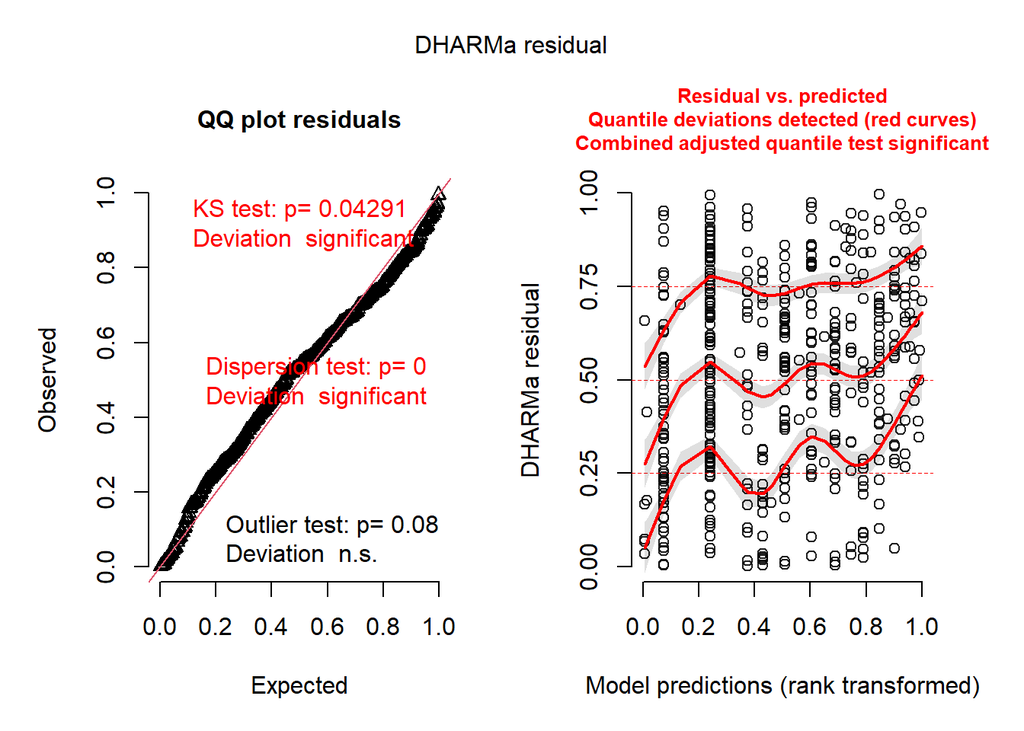

```r
abnd.brm1b <- readRDS(file = paste0(DATA_PATH, "modelled/abnd.brm1b.rds"))

#step 1. Draw out predictions
preds <- abnd.brm1b %>% posterior_predict(ndraws = 250, #extract 250 posterior draws from the posterior model
                                         summary = FALSE) #don't summarise - we want the whole distribution of them


#Step 2 create DHARMA resids
abnd.resids <- createDHARMa(simulatedResponse = t(preds), #provide with simulated predictions, transposed with t()
                            observedResponse = fish.sp.abnd$abundance, #real response
                            fittedPredictedResponse = apply(preds, 2, median), #for the fitted predicted response, use the median of preds (in the columns, the second argument of apply defines the MARGIN, 2 being columns for matrices)
                            integerResponse = "TRUE" #is the response an integer? yes
                            #, re.form = "NULL") #this argument not supported (neither in glmmTMB)
                            )

#Step 3 - plot!
plot(abnd.resids)
```

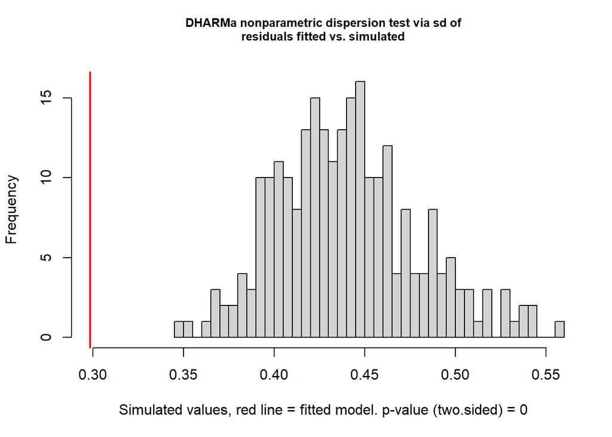

```
    DHARMa nonparametric dispersion test via sd of residuals fitted vs.
    simulated

data:  simulationOutput
dispersion = 0.67835, p-value < 2.2e-16
alternative hypothesis: two.sided
```

```r
abnd.resids %>% testDispersion()
```

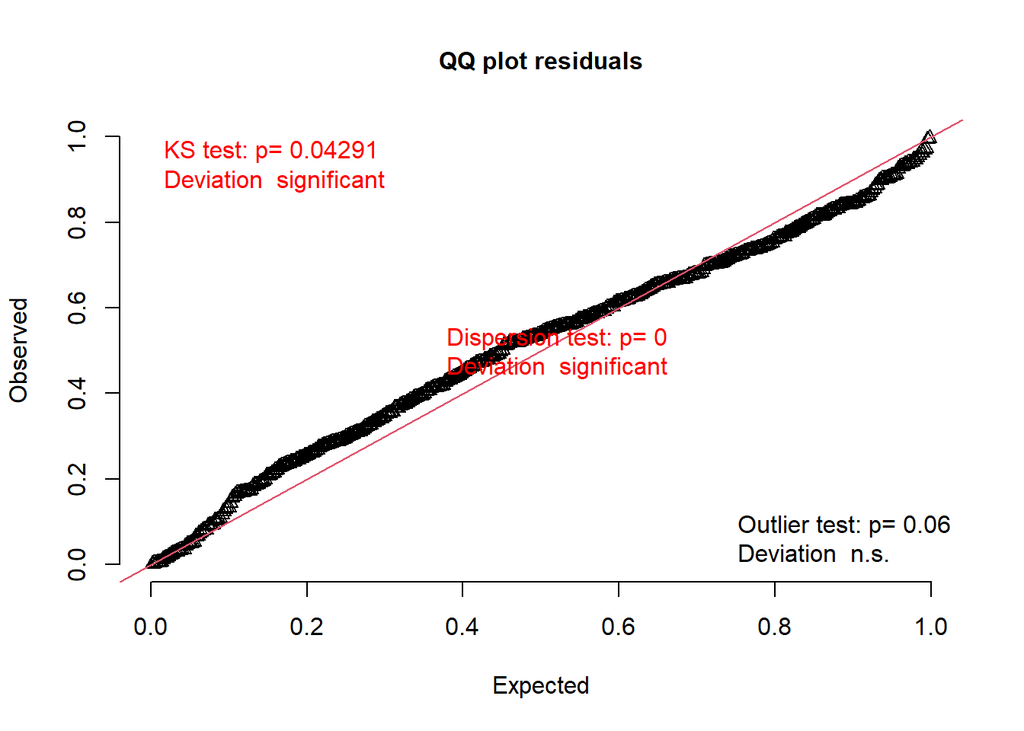

```
    Asymptotic one-sample Kolmogorov-Smirnov test

data:  simulationOutput$scaledResiduals
D = 0.065335, p-value = 0.04291
alternative hypothesis: two-sided
```

```r
abnd.resids %>% testUniformity()
```

```r
#fert.resids %>% testZeroInflation()
```

The residuals don’t look too good - similarly to the Frequentist approach, both dispersion (UNDERdispersion) and uniformity appear to be violated

However, this again is likely caused by not simulating Conditional residuals

### 4.1.5 Model Investigation

#### 4.1.5.1 1 Frequentist models

```r
abnd.glmmTMB2 %>% summary()
```

```
 Family: poisson  ( log )
Formula:          abundance ~ (1 | plotID) + Treatment
Data: fish.sp.abnd

     AIC      BIC   logLik deviance df.resid
  2397.5   2422.1  -1192.7   2385.5      449

Random effects:

Conditional model:
 Groups Name        Variance Std.Dev.
 plotID (Intercept) 0.04086  0.2021
Number of obs: 450, groups:  plotID, 25

Conditional model:
            Estimate Std. Error z value Pr(>|z|)
(Intercept)  2.10357    0.09773  21.524  < 2e-16 ***
TreatmentBQ -0.50046    0.14130  -3.542 0.000398 ***
TreatmentDL -0.41172    0.14072  -2.926 0.003436 **
TreatmentDM  0.22627    0.13714   1.650 0.098974 .
TreatmentW   0.56440    0.13600   4.150 3.32e-05 ***
---
Signif. codes:  0 '***' 0.001 '**' 0.01 '*' 0.05 '.' 0.1 ' ' 1
```

```r
r.squaredGLMM(abnd.glmmTMB2)
```

```
                R2m       R2c
delta     0.5061433 0.6372778
lognormal 0.5159844 0.6496685
trigamma  0.4956034 0.6240071
```

```r
abnd.glmmTMB.ac %>% summary()
```

```
 Family: poisson  ( log )
Formula:
abundance ~ (1 | plotID) + Treatment + (ar1(0 + factor(Date) |      plotID))
Data: fish.sp.abnd

     AIC      BIC   logLik deviance df.resid
  2318.6   2351.4  -1151.3   2302.6      447

Random effects:

Conditional model:
 Groups   Name                   Variance  Std.Dev.  Corr
 plotID   (Intercept)            3.913e-09 6.255e-05
 plotID.1 factor(Date)2022-11-25 1.078e-01 3.283e-01 0.90 (ar1)
Number of obs: 450, groups:  plotID, 25

Conditional model:
            Estimate Std. Error z value Pr(>|z|)
(Intercept)   2.0724     0.1161  17.845  < 2e-16 ***
TreatmentBQ  -0.5251     0.1672  -3.141 0.001683 **
TreatmentDL  -0.4454     0.1668  -2.670 0.007581 **
TreatmentDM   0.1792     0.1632   1.098 0.272273
TreatmentW    0.5484     0.1617   3.391 0.000696 ***
---
Signif. codes:  0 '***' 0.001 '**' 0.01 '*' 0.05 '.' 0.1 ' ' 1
```

```r
r.squaredGLMM(abnd.glmmTMB.ac)
```

```
Error in .nullFitRE.default(object, envir): object's call contains dotted names: 'glmmTMB(formula = abundance ~ (1 | plotID) + Treatment + (ar1(0 + ''    factor(Date) | plotID)), data = fish.sp.abnd, family = poisson(link = "log"), ''    ziformula = ~0, dispformula = ~1, REML = TRUE)'and cannot be e…
```

Clear differences among treatments.

Estimate of BH mean abundance: 8.1661699. Estimate for W is 1.7506725 x higher (14.2962891)

R-square estimates indicate the model without the random component of PlotID explains approximately 50% of the variance. With the random effect it explains 62% (using the trigamma method as this model has a log link, package authors recommend this). R-square calculation didn’t work for the ac model using this particular method

Planned contrasts: from Murray Logan Course notes “In frequentist analyses you can make nlevels - 1 contrasts without p adjustment - as long as they’re independent.” - however I’ve read one other source suggesting one should still apply a correction even then. I’ll leave this for now. If running Bayesian, I can make as many contrasts as I want

#### 4.1.5.2 2 Bayesian Model

2.1 Summary

```r
abnd.brm1b <- readRDS(file = paste0(DATA_PATH, "modelled/abnd.brm1b.rds"))

#abnd.brm1b %>% ggpredict(~Treatment) %>% plot(add.data = TRUE)
abnd.brm1b %>% ggemmeans(~Treatment)
```

```
# Predicted counts of abundance

Treatment | Predicted |         95% CI
--------------------------------------
BH        |      7.98 | [ 6.57,  9.69]
BQ        |      4.85 | [ 3.90,  5.89]
DL        |      5.26 | [ 4.23,  6.48]
DM        |      9.95 | [ 8.07, 12.17]
W         |     13.94 | [11.41, 17.04]
```

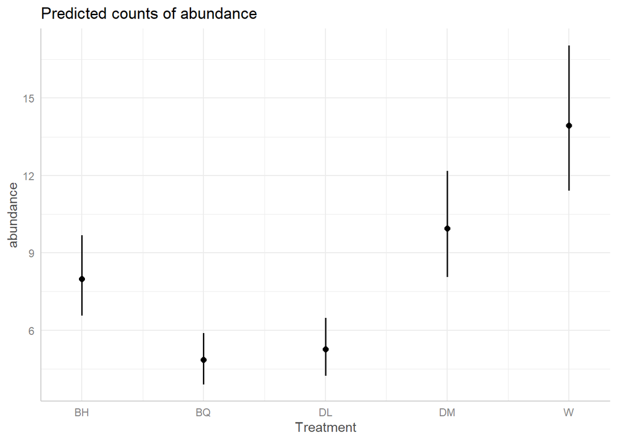

```r
abnd.brm1b %>% ggemmeans(~Treatment) %>% plot()
```

```r
abnd.brm1b$fit %>% tidyMCMC(pars = wch,
                             estimate.method = "median",
                             conf.int = TRUE,
                             conf.method = "HPDinterval",
                             rhat = TRUE,
                             ess = TRUE)
```

```
# A tibble: 8 × 7
  term                 estimate std.error conf.low conf.high  rhat   ess
  <chr>                   <dbl>     <dbl>    <dbl>     <dbl> <dbl> <int>
1 b_Intercept             2.08     0.101    1.88       2.27  1.00   2112
2 b_TreatmentBQ          -0.500    0.149   -0.808     -0.222 1.00   2436
3 b_TreatmentDL          -0.418    0.148   -0.716     -0.139 1.00   2440
4 b_TreatmentDM           0.223    0.143   -0.0557     0.508 1.00   2166
5 b_TreatmentW            0.557    0.140    0.271      0.843 1.00   2100
6 ar[1]                   0.801    0.141    0.524      0.999 1.00   2276
7 sderr                   0.168    0.0228   0.128      0.217 0.999  2109
8 sd_plotID__Intercept    0.196    0.0459   0.121      0.298 1.00   2147
```

```r
#Conditional
abnd.brm1b %>% bayes_R2(re.form = ~(1|plotID),
                        summary = FALSE) %>% #don't summarise - I want ALL the R-squareds
  median_hdci # get the hdci of the r2
```

```
          y      ymin     ymax .width .point .interval
1 0.6351792 0.5840081 0.691339   0.95 median      hdci
```

although ‘ggpredict()’ is having some trouble, ggemmeans works well

The summary stat table shows differences amongst treatments, will explore further contrasts (e.g. W vs the rest) next because I can

the estimate of ar(1) is slightly lower compared to the Frequentist analysis

```r
abnd.brm1b <- readRDS(file = paste0(DATA_PATH, "modelled/abnd.brm1b.rds"))
abnd.brm1b %>% brms::bayes_R2(
  re.form = NA,
  summary = FALSE
) %>%
  median_hdci()
```

```
          y      ymin      ymax .width .point .interval
1 0.5572066 0.4269932 0.6634504   0.95 median      hdci
```

```r
abnd.brm1b %>% brms::bayes_R2(
  re.form = NULL,
  summary = FALSE
) %>%
  median_hdci()
```

```
          y      ymin     ymax .width .point .interval
1 0.6351792 0.5840081 0.691339   0.95 median      hdci
```

2.2 Hypothesis testing

```r
abnd.brm1b <- readRDS(file = paste0(DATA_PATH, "modelled/abnd.brm1b.rds"))

abnd.brm1b %>%
  emmeans(~Treatment, type = "response") %>%
  pairs()
```

```
 contrast ratio lower.HPD upper.HPD
 BH / BQ  1.648     1.195     2.161
 BH / DL  1.519     1.102     1.994
 BH / DM  0.800     0.601     1.057
 BH / W   0.573     0.419     0.747
 BQ / DL  0.920     0.654     1.206
 BQ / DM  0.488     0.359     0.635
 BQ / W   0.348     0.250     0.452
 DL / DM  0.528     0.384     0.698
 DL / W   0.378     0.266     0.488
 DM / W   0.713     0.516     0.926

Results are averaged over the levels of: Date, plotID
Point estimate displayed: median
Results are back-transformed from the log scale
HPD interval probability: 0.95
```

```r
abnd.brm1b %>%
  emmeans(~Treatment, type = "link") %>%
  pairs() %>%
  gather_emmeans_draws() %>%
  summarise(
    "P>" = sum(.value > 0) / n(),
    "P<" = sum(.value < 0) / n(),
  )
```

```
# A tibble: 10 × 3
   contrast   `P>`     `P<`
   <chr>     <dbl>    <dbl>
 1 BH - BQ  1.00   0.000417
 2 BH - DL  0.995  0.005
 3 BH - DM  0.0579 0.942
 4 BH - W   0      1
 5 BQ - DL  0.29   0.71
 6 BQ - DM  0      1
 7 BQ - W   0      1
 8 DL - DM  0      1
 9 DL - W   0      1
10 DM - W   0.0117 0.988
```

There is very strong evidence (>99%) that treatment BH had higher fish recruitment than BQ and DL, that W had higher recruitment than BH, BQ and DL, and that DM had higher recruitment than BQ and DL. There was strong evidence (>95%) that W had higher recruitment than DM.There was evidence (>90%) that DM had higher recruitment than BH. There was no evidence (<90%) for a difference between BQ and DL

Compare: Natural vs Reduced Biomass: Mean of DL, DM and W vs Mean of BH and BQ High vs Reduced Density: Mean of BH, BQ and W vs Mean of DL and DM All vs Low Density: DL vs the rest

```r
cmat <- cbind(
  "Biomass.NatvsLess" = c(-1 / 2, -1 / 2, 1 / 3, 1 / 3, 1 / 3),
  "Biomass.All.Vs.Low" = c(1 / 4, -1, 1 / 4, 1 / 4, 1 / 4),
  "Density.9vsLess" = c(1 / 3, 1 / 3, -1 / 2, -1 / 2, 1 / 3),
  "Density.All.Vs.Low" = c(1 / 4, 1 / 4, -1, 1 / 4, 1 / 4)
)
cmat %>% rowSums()
```

```
[1]  0.3333333 -0.9166667 -0.9166667  0.3333333  1.1666667
```

```r
abnd.brm1b %>%
  emmeans(~Treatment, type = "link") %>%
  contrast(method = list(Treatment = cmat)) %>%
  gather_emmeans_draws() %>%
  summarise(
    "P>" = sum(.value > 0) / n(),
    "P<" = sum(.value < 0) / n()
  )
```

```
# A tibble: 4 × 3
  contrast                      `P>`   `P<`
  <chr>                        <dbl>  <dbl>
1 Treatment.Biomass.All.Vs.Low 1     0
2 Treatment.Biomass.NatvsLess  1     0
3 Treatment.Density.9vsLess    0.902 0.0983
4 Treatment.Density.All.Vs.Low 1     0
```

However there was strong evidence that total recruitment was reduced at the low extremes of both biomas and density compared to the average recruitment of the other treatments. (perhaps not the most sensible contrast)

```r
abnd.brm1b <- readRDS(file = paste0(DATA_PATH, "modelled/abnd.brm1b.rds"))

newdata <- abnd.brm1b %>%
  emmeans(~Treatment, type = "link") %>%
  gather_emmeans_draws() %>%
  mutate(Fit = exp(.value)) %>%
  as.data.frame()
head(newdata)
```

```
  Treatment .chain .iteration .draw   .value      Fit
1        BH     NA         NA     1 2.136558 8.470231
2        BH     NA         NA     2 2.118679 8.320139
3        BH     NA         NA     3 2.144219 8.535369
4        BH     NA         NA     4 2.130000 8.414864
5        BH     NA         NA     5 2.168489 8.745059
6        BH     NA         NA     6 1.948407 7.017498
```

```r
g1 <- newdata %>% ggplot() +
  stat_slab(aes(
    x = Treatment, y = Fit,
    fill = stat(ggdist::cut_cdf_qi(cdf,
      .width = c(0.5, 0.8, 0.95),
      labels = scales::percent_format()
    ))
  ), color = "black") +
  scale_fill_brewer("Interval", direction = -1, na.translate = FALSE) +
  ylab("Total Abundance") +
  theme_classic()

abnd.em <- abnd.brm1b %>%
  emmeans(~Treatment, type = "link") %>%
  pairs() %>%
  gather_emmeans_draws() %>%
  mutate(Fit = exp(.value)) %>%
  as.data.frame()
head(abnd.em)
```

```
  contrast .chain .iteration .draw    .value      Fit
1  BH - BQ     NA         NA     1 0.3941744 1.483159
2  BH - BQ     NA         NA     2 0.5775062 1.781590
3  BH - BQ     NA         NA     3 0.4961378 1.642366
4  BH - BQ     NA         NA     4 0.6010352 1.824006
5  BH - BQ     NA         NA     5 0.8087755 2.245157
6  BH - BQ     NA         NA     6 0.4315199 1.539596
```

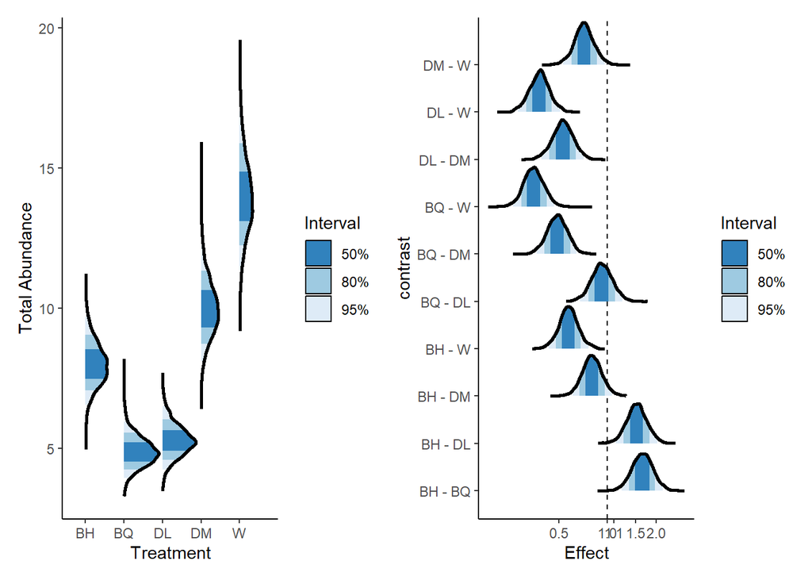

```r
g2 <- abnd.em %>%
  ggplot() +
  geom_vline(xintercept = 1, linetype = "dashed") +
  stat_slab(aes(
    x = Fit, y = contrast,
    fill = stat(ggdist::cut_cdf_qi(cdf,
      .width = c(0.5, 0.8, 0.95),
      labels = scales::percent_format()
    ))
  ), color = "black") +
  scale_fill_brewer("Interval", direction = -1, na.translate = FALSE) +
  scale_x_continuous("Effect",
    trans = scales::log2_trans(),
    breaks = c(0.1, 0.5, 1, 1.1, 1.5, 2, 4)
  ) +
  theme_classic()
g1 + g2
```

See bglm_example5.html for fancy figure code. Need to fix X axis labels in g2 and perhaps make the ‘stat_slab’ object end at the 95% intervals in g1

## 4.2 Species Richness

### 4.2.1 Fit model

```r
sp.glmmTMB1 <- glmmTMB(sp.richness ~ 1 + (1 | plotID),
  data = fish.sp.abnd,
  family = poisson(link = "log"),
  REML = TRUE
)
sp.glmmTMB2 <- update(sp.glmmTMB1, . ~ . + Treatment)

sp.glmmTMB3 <- update(sp.glmmTMB1, . ~ . + plot.weight)

sp.glmmTMB4 <- update(sp.glmmTMB1, . ~ . + Density)

sp.glmmTMB5 <- update(sp.glmmTMB3, . ~ . + Density)

sp.glmmTMB6 <- update(sp.glmmTMB3, . ~ . * Density)

sp.glmmTMB7 <- update(sp.glmmTMB2, ~ . + plot.weight)

sp.glmmTMB8 <- update(sp.glmmTMB2, ~ . * plot.weight)

MuMIn::AICc(
  sp.glmmTMB1, sp.glmmTMB2, sp.glmmTMB3, sp.glmmTMB4,
  sp.glmmTMB5, sp.glmmTMB6, sp.glmmTMB7, sp.glmmTMB8
)
```

```
            df     AICc
sp.glmmTMB1  2 1684.908
sp.glmmTMB2  6 1671.339
sp.glmmTMB3  3 1680.060
sp.glmmTMB4  4 1685.147
sp.glmmTMB5  5 1682.131
sp.glmmTMB6  8 1700.757
sp.glmmTMB7  7 1685.114
sp.glmmTMB8 12 1712.342
```

As with abundance, the Treatment + RE of plot model performed best, despite consuming more df

###Validate/Refit

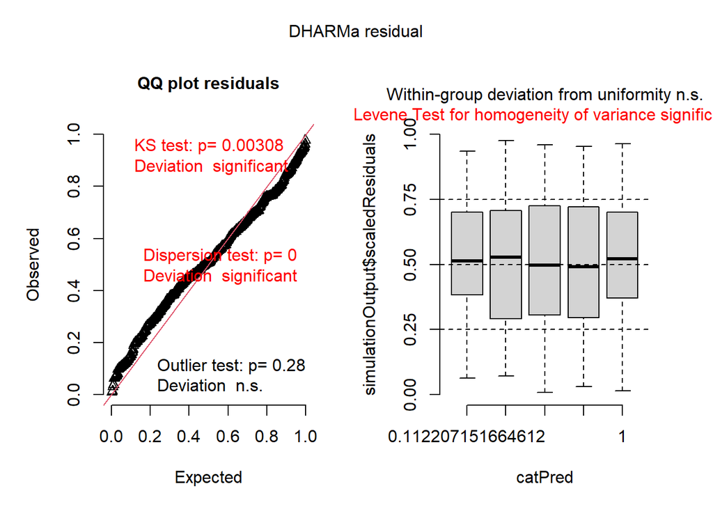

```r
sp.resid <- sp.glmmTMB2 %>% simulateResiduals(plot = TRUE)
```

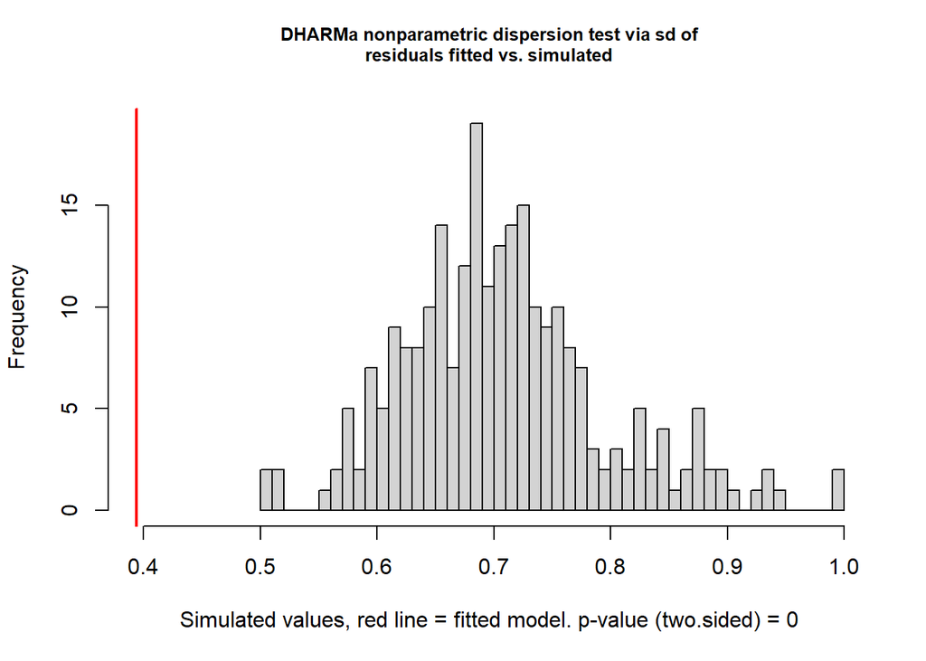

```
    DHARMa nonparametric dispersion test via sd of residuals fitted vs.
    simulated

data:  simulationOutput
dispersion = 0.55591, p-value < 2.2e-16
alternative hypothesis: two.sided
```

```r
sp.resid %>% testDispersion()
```

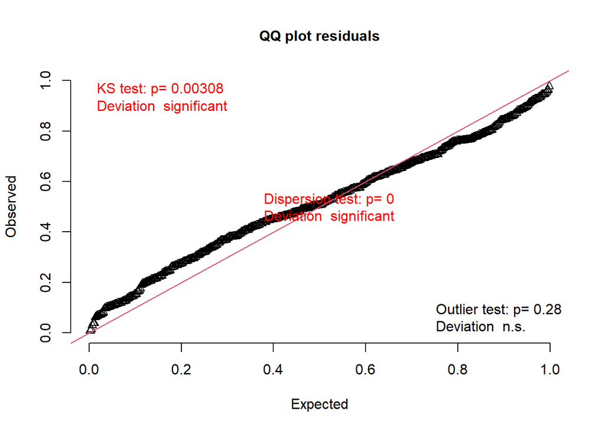

```
    Asymptotic one-sample Kolmogorov-Smirnov test

data:  simulationOutput$scaledResiduals
D = 0.084832, p-value = 0.003077
alternative hypothesis: two-sided
```

```r
sp.resid %>% testUniformity()
```

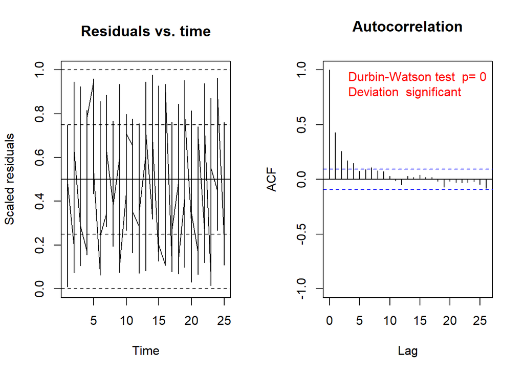

```
    Durbin-Watson test

data:  simulationOutput$scaledResiduals ~ 1
DW = 1.1405, p-value < 2.2e-16
alternative hypothesis: true autocorrelation is not 0
```

```r
#showing problems (underdispersion)
fish.sp.abnd <- fish.sp.abnd %>%
  mutate(TIME = as.numeric(plotID) + as.numeric(Date)*10^-5)

sp.resid %>% testTemporalAutocorrelation(time = fish.sp.abnd$TIME)
```

```r
#definitely autocorrelation
```

The residuals are showing signs of underdispersion (i.e. results more conservative). The Levene test is also warning that the homogeneity of variance assumption is violated. However the box plots look ok to me

Despite there being evidence of autocorrelation, the ac model performed about the same (within 2 AICc) as the previous model. However I think the autocorrelation is important enough to need dealing with

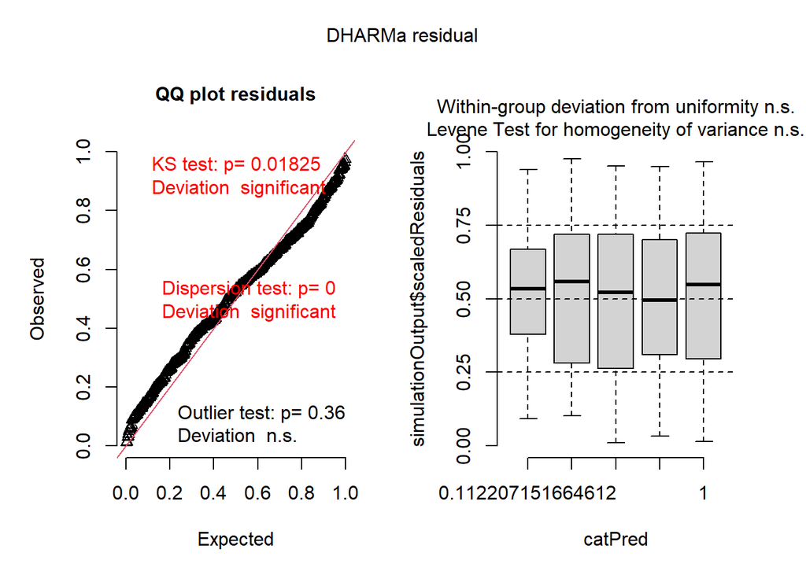

```r
sp.glmmTMB.ac <- readRDS(file = paste0(DATA_PATH, "modelled/sp.glmmTMB.ac.rds"))

sp.ac.resid <- sp.glmmTMB.ac %>% simulateResiduals(plot = TRUE)
```

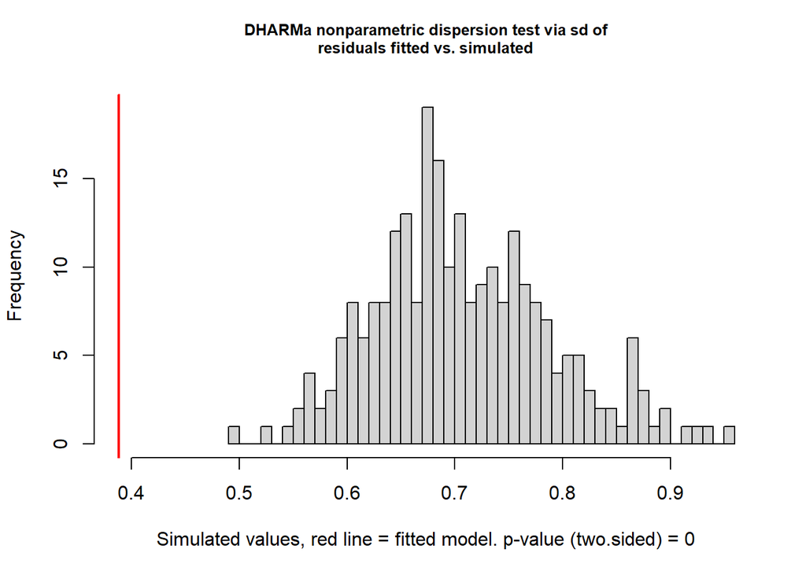

```
    DHARMa nonparametric dispersion test via sd of residuals fitted vs.
    simulated

data:  simulationOutput
dispersion = 0.54878, p-value < 2.2e-16
alternative hypothesis: two.sided
```

```r
sp.ac.resid %>% testDispersion()
```

Similar problems evident (underdispersion), but without the red flag for the Levene test

### 4.2.2 Partial Plot

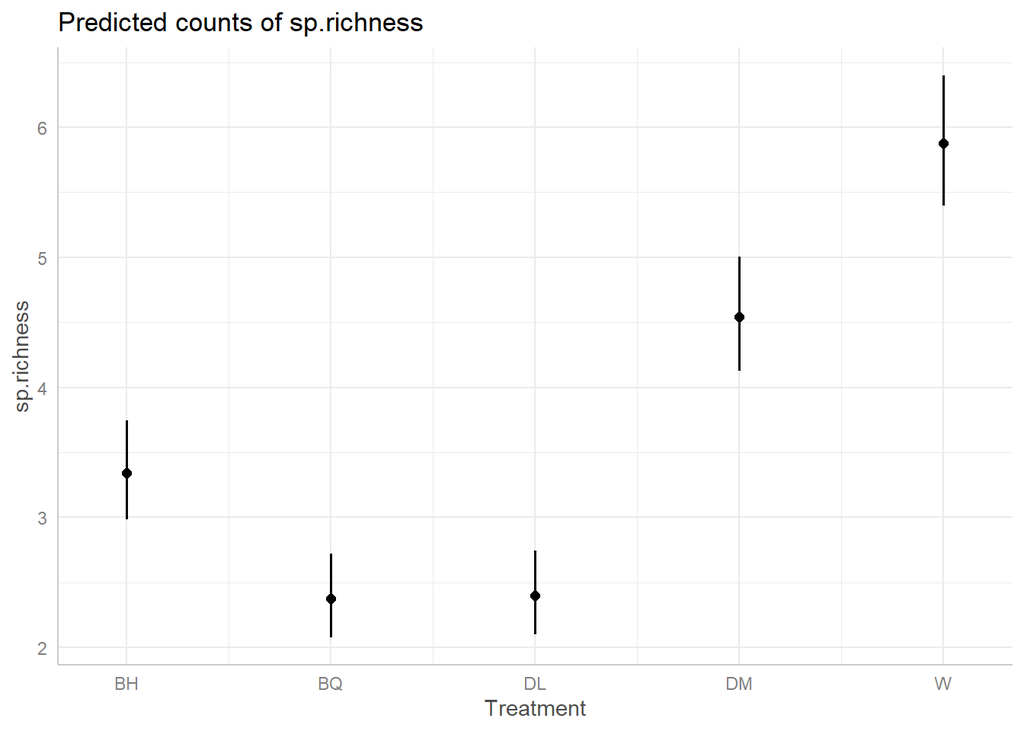

```r
sp.glmmTMB.ac %>%
  ggpredict(Terms = "Treatment") %>%
  plot()
```

### 4.2.3 Bayesian Model

####1 Initial priors

```r
sp.form <- bf(
  sp.richness ~ Treatment
    + (1 | plotID),
  autocor = ~ ar(
    time = Date, gr = plotID,
    p = 1
  ),
  family = poisson(link = "log")
)
fish.sp.abnd %>%
  group_by(Treatment) %>%
  summarise(
    log(median(sp.richness)),
    log(mad(sp.richness))
  )
```

```
# A tibble: 5 × 3
  Treatment `log(median(sp.richness))` `log(mad(sp.richness))`
  <fct>                          <dbl>                   <dbl>
1 BH                             1.10                    0.394
2 BQ                             0.693                   0.394
3 DL                             0.693                   0.394
4 DM                             1.39                    0.394
5 W                              1.79                    0.394
```

As the model formula is so similar to that of the abundance model, the same priors will need specification.

For the Intercept, an appropriate prior might be 1, 0.4

Again, the standard deviation of the response divided by the standard deviation of the predictor will be used to estimate an appropriate prior for the slopes:

```r
##priors for Effects
log(sd(fish.sp.abnd$sp.richness)) #.73
```

```
[1] 0.7319329
```

```r
#model.matrix(~Treatment, data = fish.sp.abnd) %>% head
apply(model.matrix(~Treatment, data = fish.sp.abnd), 2, sd)
```

```
(Intercept) TreatmentBQ TreatmentDL TreatmentDM  TreatmentW
  0.0000000   0.4004452   0.4004452   0.4004452   0.4004452
```

```r
log(sd(fish.sp.abnd$sp.richness))/apply(model.matrix(~Treatment, data = fish.sp.abnd), 2, sd)
```

```
(Intercept) TreatmentBQ TreatmentDL TreatmentDM  TreatmentW
        Inf    1.827798    1.827798    1.827798    1.827798
```

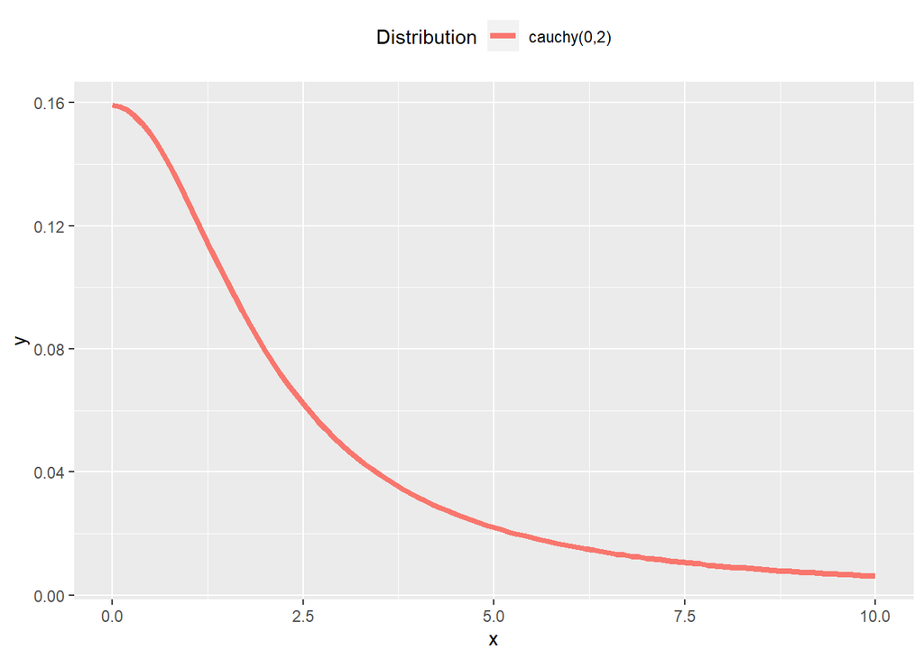

```r
##prior for sds
standist::visualize("cauchy(0,2)", xlim = c(0,10))
```

N(0,2) might be appropriate for the slopes

Again, I’ll try a cauchy(0,2) for sd and sderr

```r
sp.form <- bf(
  sp.richness ~ Treatment
    + (1 | plotID),
  family = poisson(link = "log")
)

priors <- prior(normal(1, 0.4), class = "Intercept") +
  prior(normal(0, 2), class = "b") +
  prior(cauchy(0, 2), class = "sd")

sp.brm1 <- brm(sp.form,
  data = fish.sp.abnd,
  prior = priors,
  sample_prior = "only",
  iter = 5000, warmup = 1000,
  chains = 3, cores = 3,
  thin = 5
)
```

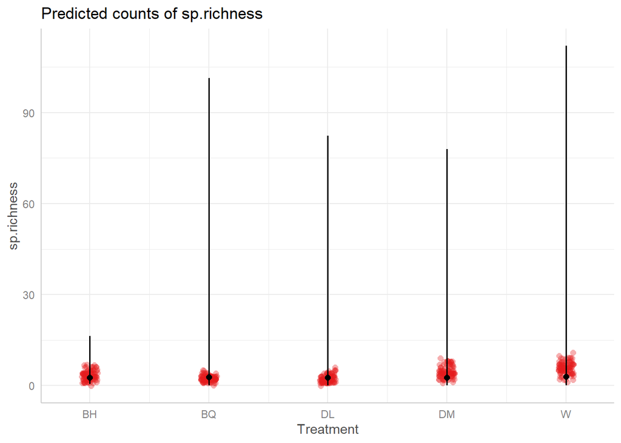

```r
load(file = paste0(DATA_PATH, "modelled/sp.brmprior1.RData"))

sp.brm1 %>%
  ggpredict(~Treatment) %>%
  plot(add.data = TRUE)
```

Priors quite wide compared with data. Remember this is not in itself a problem, unless we find evidence later

####2 Fitting

```r
sp.form <- bf(
  sp.richness ~ Treatment
    + (1 | plotID),
  autocor = ~ ar(
    time = Date, gr = plotID,
    p = 1
  ),
  family = poisson(link = "log")
)

priors <- prior(normal(1, 0.4), class = "Intercept") +
  prior(normal(0, 2), class = "b") +
  prior(cauchy(0, 2), class = "sd") +
  prior(cauchy(0, 2), class = "sderr") +
  prior(uniform(0, 1), class = "ar")

sp.brm1a <- brm(sp.form,
  data = fish.sp.abnd,
  prior = priors,
  sample_prior = "yes",
  iter = 5000, warmup = 1000,
  chains = 3, cores = 3,
  thin = 5
)

sp.brm1a %>%
  hack_size.brmsfit() %>%
  saveRDS(file = paste0(DATA_PATH, "modelled/sp.brm1.rds"))
```

2048 divergent transitions occurred, out of a possible 2400. Also note that the size of of both brmsfits (sp.brm1 and sp.brm1a) are apparently of size 0B in the environment (though their saved file sizes seem similar to those of the abnd models)

####3 Prior Checks

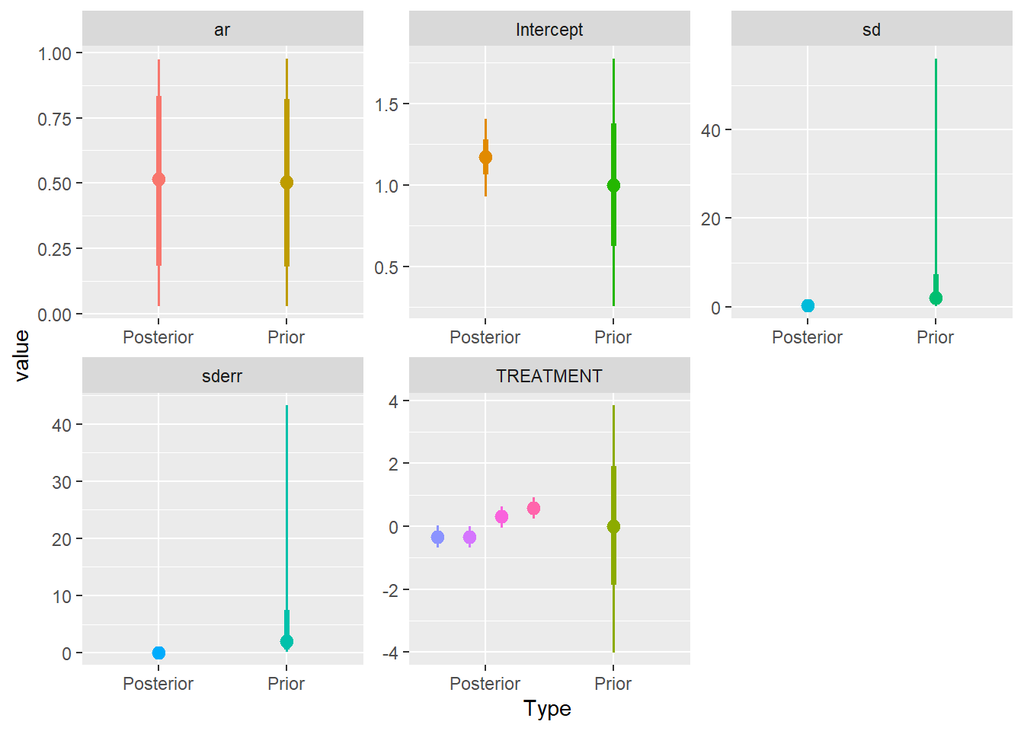

```r
sp.brm1a <- readRDS(file = paste0(DATA_PATH, "modelled/sp.brm1.rds"))

sp.brm1a %>%
  as_draws_df() %>%

  dplyr::select(!matches("^lp|^err|^r_|^\\.")) %>%

  pivot_longer(everything(), names_to = "key") %>%

  mutate(
    Type = ifelse(str_detect(key, "prior"), "Prior", "Posterior"),
    Class = case_when(
      str_detect(key, "(^b|^prior).*Intercept$") ~ "Intercept",
      str_detect(key, "b_Treatment.*|prior_b") ~ "TREATMENT",
      str_detect(key, "sd_") ~ "sd",
      str_detect(key, "ar") ~ "ar",
      str_detect(key, "sderr") ~ "sderr"
    ),
    Par = str_replace(key, "b_", "")
  ) %>%
  ggplot(aes(x = Type, y = value, color = Par)) +
  stat_pointinterval(position = position_dodge(), show.legend = FALSE) +
  facet_wrap(~Class, scales = "free")
```

Prior seems appropriate for effects, and for the intercept they could maybe go slightly wider. sd and sderr priors are very wide, so could come in a bit (but see prior checks for abundance - very similar). Prior for ar however looks identical to the posterior, despite autocorrelation being similar or greater (0.98 according to summary(sp.glmmTMB.ac), Durbin-Watson test p < 2.2e-16) than for abundance

####4 MCMC Diagnostics

Trace plots look good, resembling noise and each chain resembles the rest Rhats fine (close to 1, not over 1.05) Density overlay looks pretty good

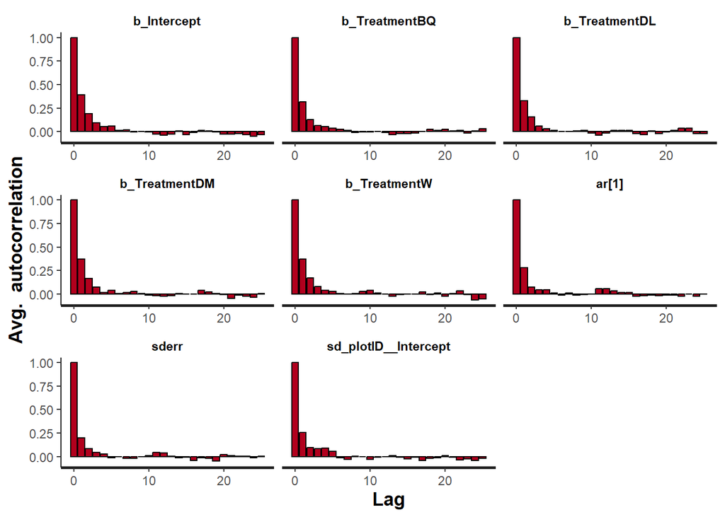

```r
stan_ac(sp.brm1a$fit, pars = wch)
```

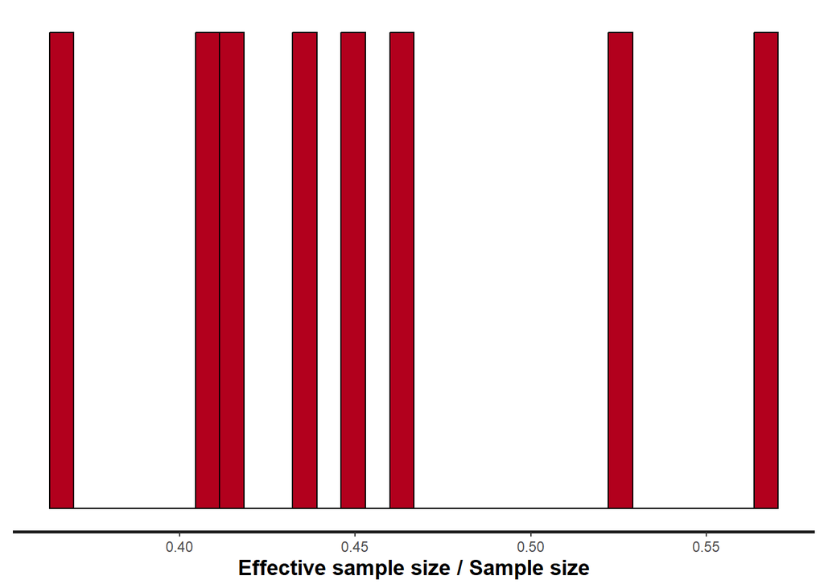

```r
stan_ess(sp.brm1a$fit, pars = wch)
```

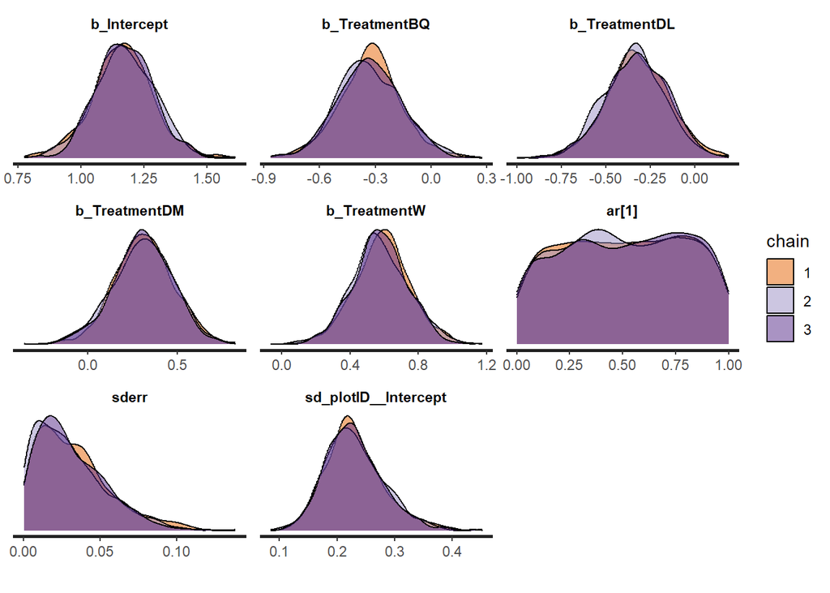

```r
stan_dens(sp.brm1a$fit, pars = wch, separate_chains = TRUE)
```

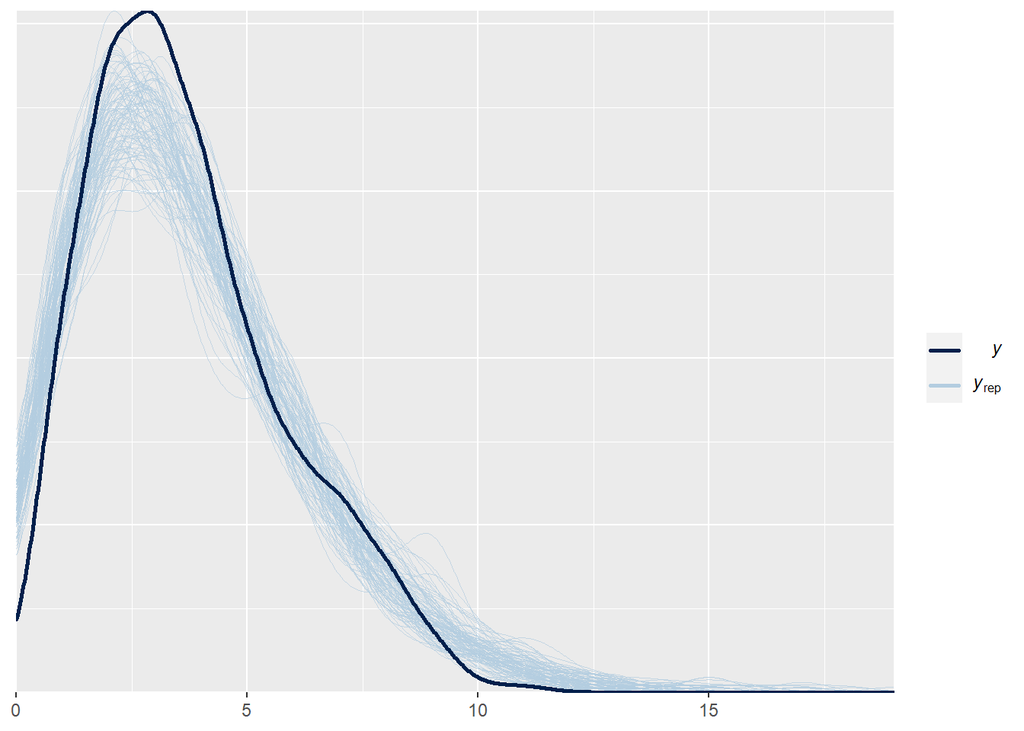

```r
sp.brm1a %>% pp_check(type = "dens_overlay", ndraws = 100)
```

AC - all have values of >0.2 at first lag - increase thinning? ESS - most values below 0.5, none over 0.6 - priors too wide? adapt delta adjustment? Density plot shows no real mode for ar The density overlay shows the very low values of sp.richness and the most common values of sp.richness aren’t being that well captured by the model (which is predicting more and fewer of these values, respectively)

Options: adapt_delta to 0.99 Shrink priors for sd and sderr ar prior?? adjust thinning factor

####4.1 Refitting, rechecking

```r
standist::visualize("cauchy(0,2)", "cauchy(0,1)", "cauchy(0,0.5)", xlim = c(0, 10))
priors <- prior(normal(1, 0.5), class = "Intercept") +
  prior(normal(0, 2), class = "b") +
  prior(cauchy(0, .5), class = "sd") +
  prior(cauchy(0, .5), class = "sderr") +
  prior(uniform(0, 1), class = "ar")
sp.brm1d <- brm(sp.form,
  data = fish.sp.abnd,
  prior = priors,
  sample_prior = "yes",
  iter = 10000, warmup = 2000,
  chains = 3, cores = 3,
  thin = 10
)
sp.brm1d %>%
  hack_size.brmsfit() %>%
  saveRDS(file = paste0(DATA_PATH, "modelled/sp.brm1d.rds"))
```

2121 divergent transitions

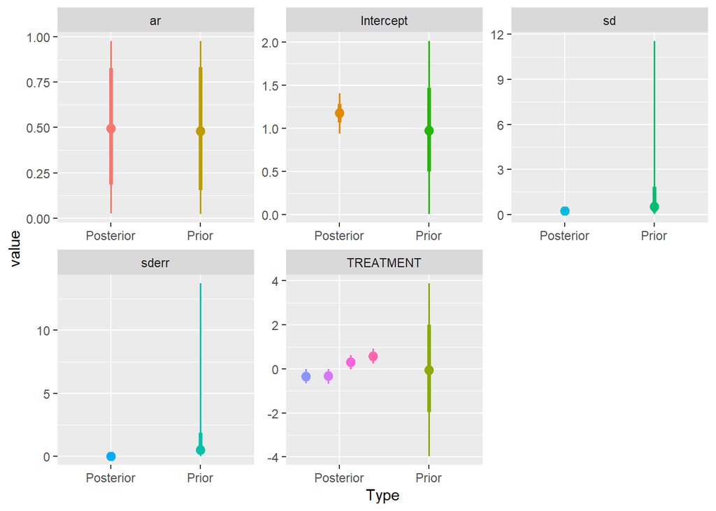

```r
sp.brm1d <- readRDS(file = paste0(DATA_PATH, "modelled/sp.brm1d.rds"))


sp.brm1d %>%
  as_draws_df() %>%

  dplyr::select(!matches("^lp|^err|^r_|^\\.")) %>%

  pivot_longer(everything(), names_to = "key") %>%

  mutate(
    Type = ifelse(str_detect(key, "prior"), "Prior", "Posterior"),
    Class = case_when(
      str_detect(key, "(^b|^prior).*Intercept$") ~ "Intercept",
      str_detect(key, "b_Treatment.*|prior_b") ~ "TREATMENT",
      str_detect(key, "sd_") ~ "sd",
      str_detect(key, "ar") ~ "ar",
      str_detect(key, "sderr") ~ "sderr"
    ),
    Par = str_replace(key, "b_", "")
  ) %>%
  ggplot(aes(x = Type, y = value, color = Par)) +
  stat_pointinterval(position = position_dodge(), show.legend = FALSE) +
  facet_wrap(~Class, scales = "free")
```

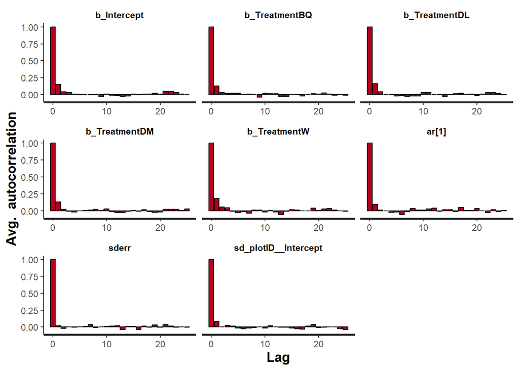

```r
stan_ac(sp.brm1d$fit, pars = wch)
```

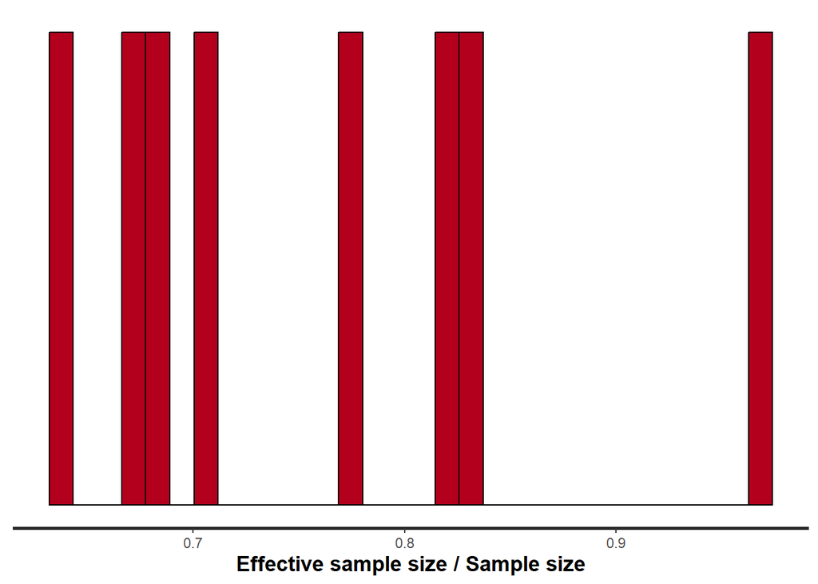

```r
stan_ess(sp.brm1d$fit, pars = wch)
```

ess and ac now acceptable

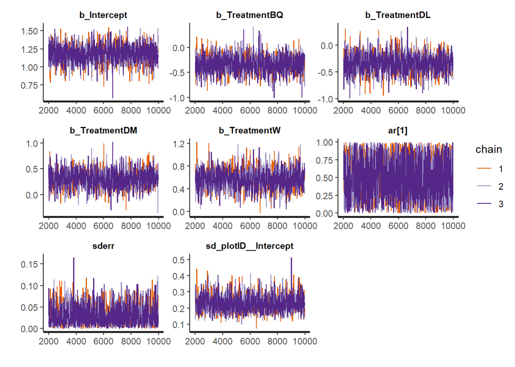

```r
stan_trace(sp.brm1d$fit, pars = wch)
```

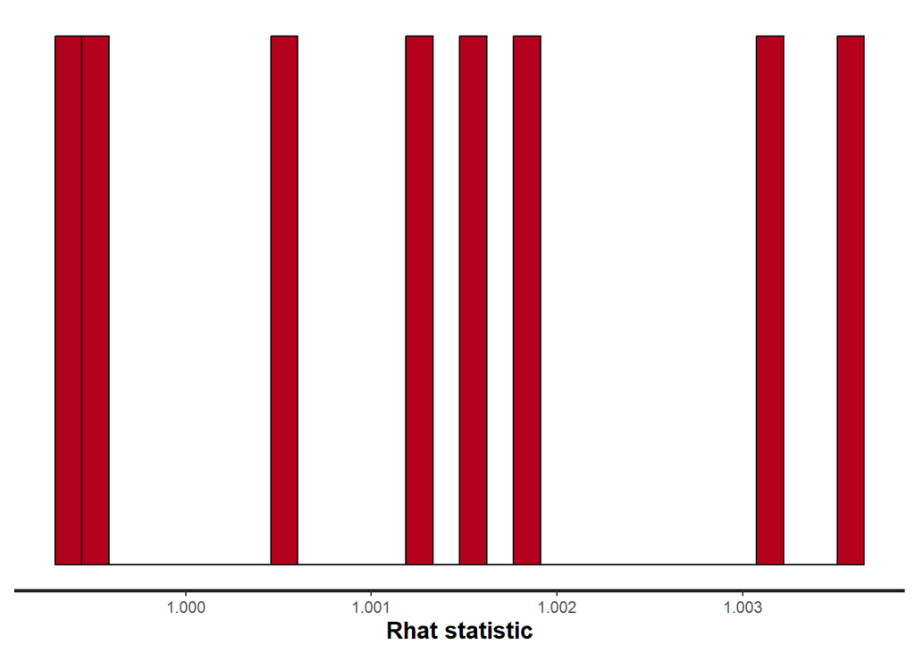

```r
stan_rhat(sp.brm1d$fit, pars = wch)
```

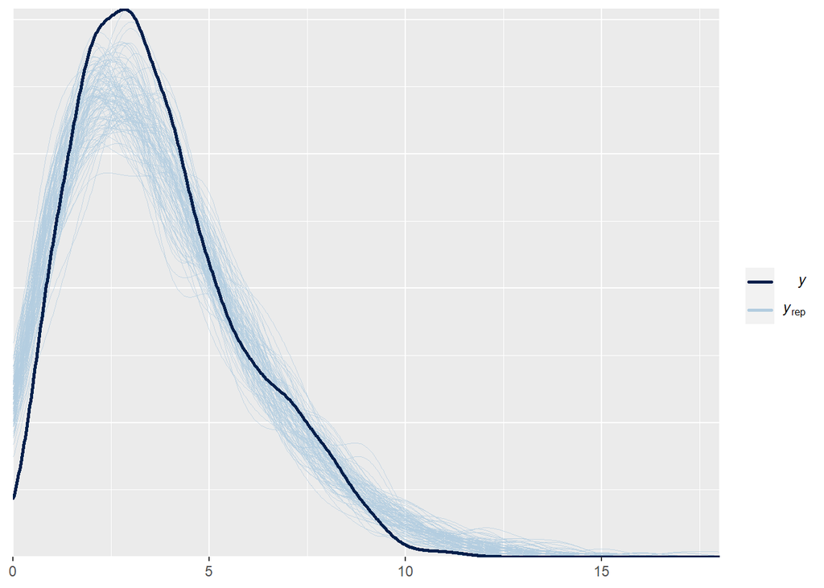

```r
sp.brm1d %>% pp_check(type = "dens_overlay", ndraws = 100)
```

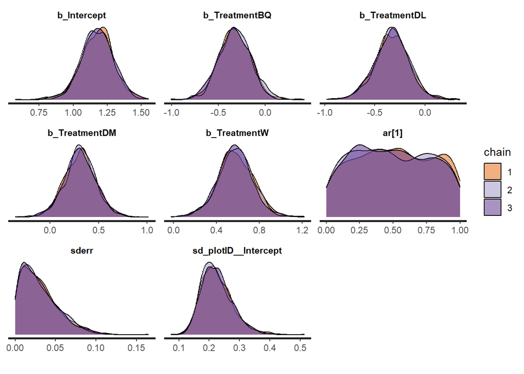

```r
sp.brm1d$fit %>% stan_dens(pars = wch, separate_chains = TRUE)
```

all other mcmc diagnostics now acceptable, but the posteriors for ac are worrying - no consistent mode (particularly not near the frequentist derived estimate of 0.98)

```r
priors <- prior(normal(1, 0.5), class = "Intercept") +
  prior(normal(0, 2), class = "b") +
  prior(cauchy(0, 1), class = "sd") +
  prior(cauchy(0, 1), class = "sderr") +
  prior(uniform(-1, 1), class = "ar")

sp.brm1f <- update(sp.brm1d, prior = priors)
sp.brm1f %>%
  hack_size.brmsfit() %>%
  saveRDS(file = paste0(DATA_PATH, "modelled/sp.brm1f.rds"))
```

This model had no divergent transitions

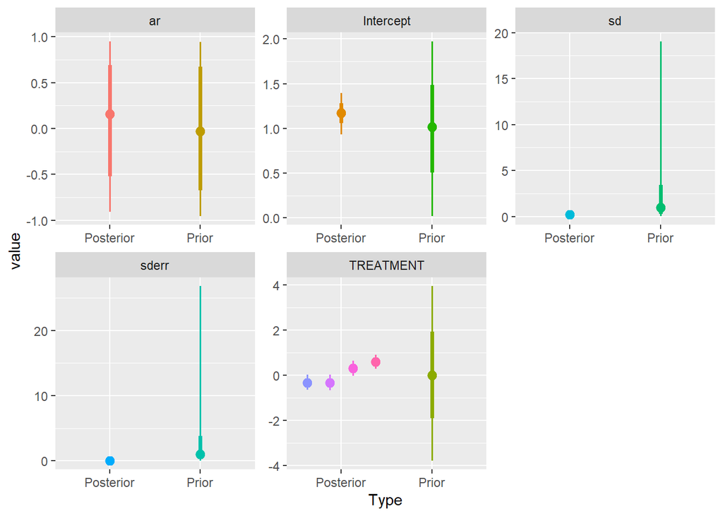

```r
sp.brm1f <- readRDS(file = paste0(DATA_PATH, "modelled/sp.brm1f.rds"))

sp.brm1f %>%
  as_draws_df() %>%

  dplyr::select(!matches("^lp|^err|^r_|^\\.")) %>%

  pivot_longer(everything(), names_to = "key") %>%

  mutate(
    Type = ifelse(str_detect(key, "prior"), "Prior", "Posterior"),
    Class = case_when(
      str_detect(key, "(^b|^prior).*Intercept$") ~ "Intercept",
      str_detect(key, "b_Treatment.*|prior_b") ~ "TREATMENT",
      str_detect(key, "sd_") ~ "sd",
      str_detect(key, "ar") ~ "ar",
      str_detect(key, "sderr") ~ "sderr"
    ),
    Par = str_replace(key, "b_", "")
  ) %>%
  ggplot(aes(x = Type, y = value, color = Par)) +
  stat_pointinterval(position = position_dodge(), show.legend = FALSE) +
  facet_wrap(~Class, scales = "free")
```

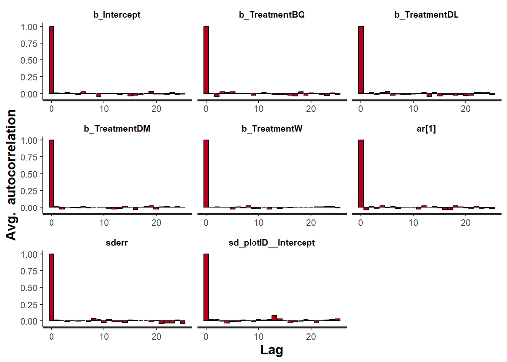

```r
stan_ac(sp.brm1f$fit, pars = wch)
```

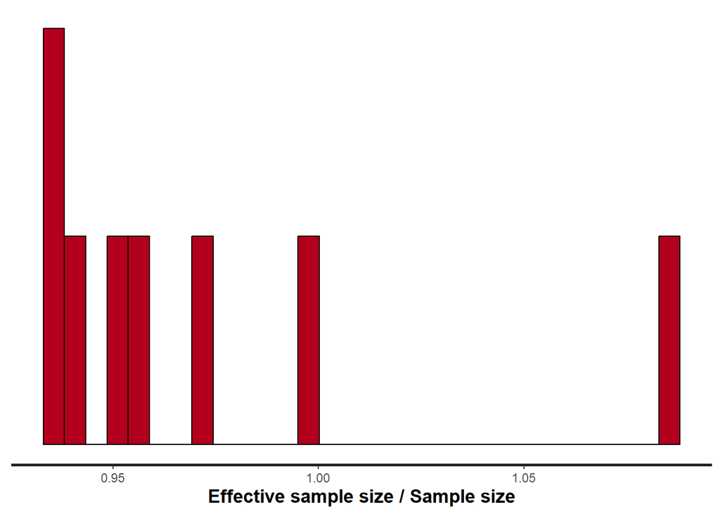

```r
stan_ess(sp.brm1f$fit, pars = wch)
```

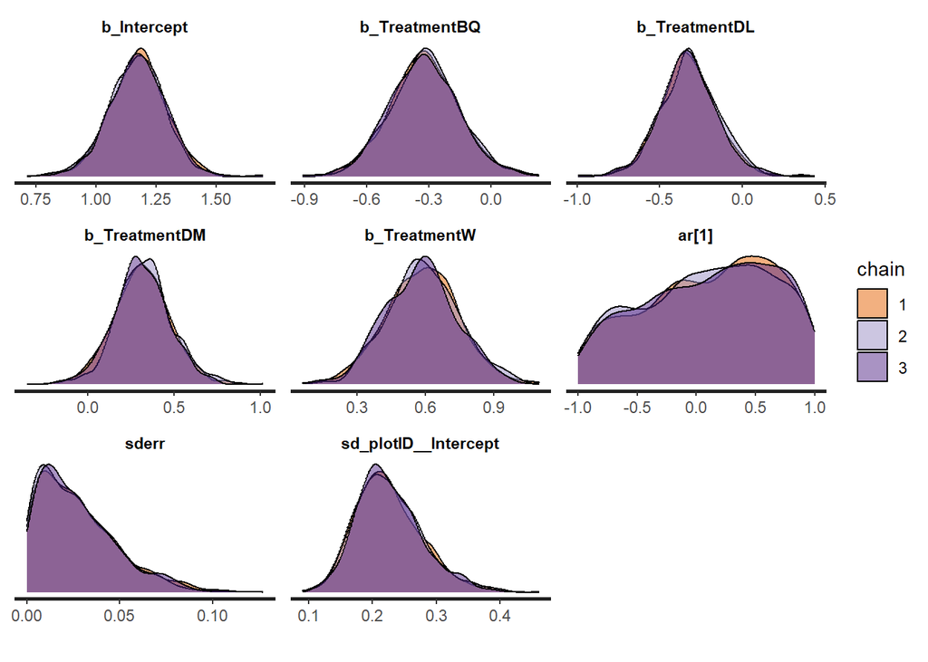

```r
sp.brm1f$fit %>% stan_dens(pars = wch, separate_chains = TRUE)
```

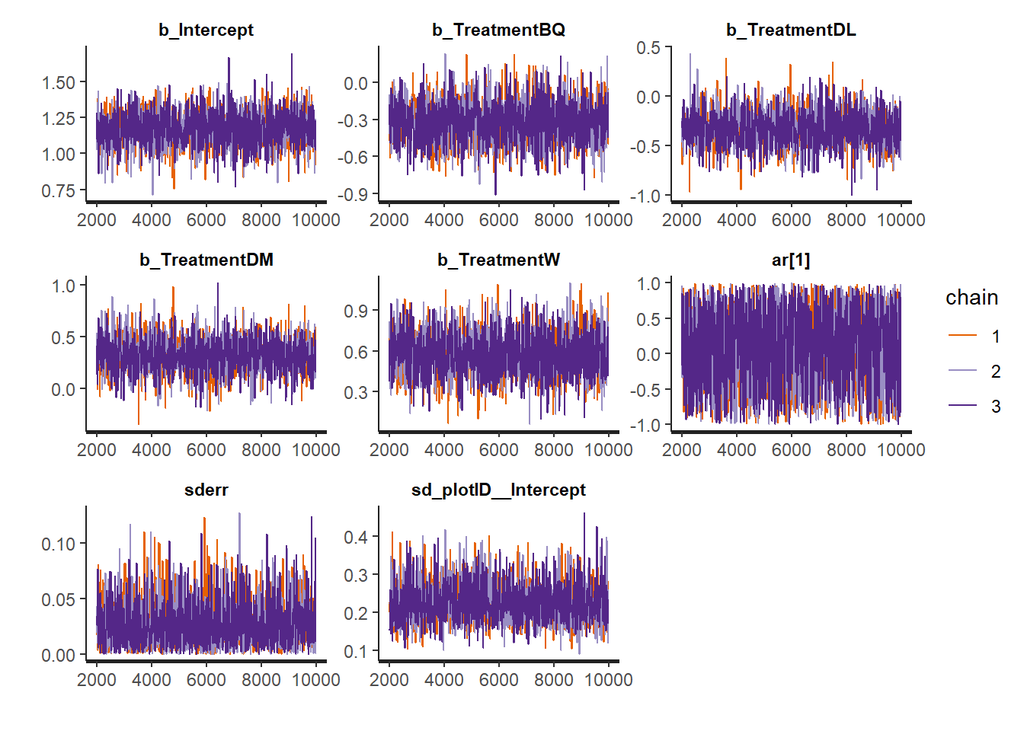

```r
stan_trace(sp.brm1f$fit, pars = wch)
```

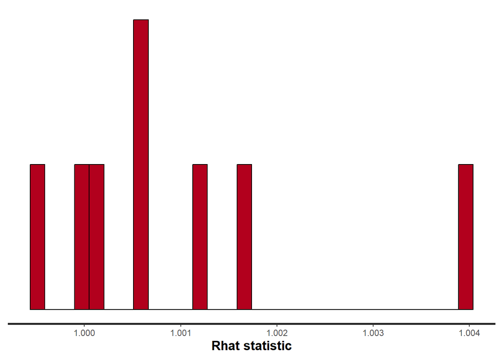

```r
stan_rhat(sp.brm1f$fit, pars = wch)
```

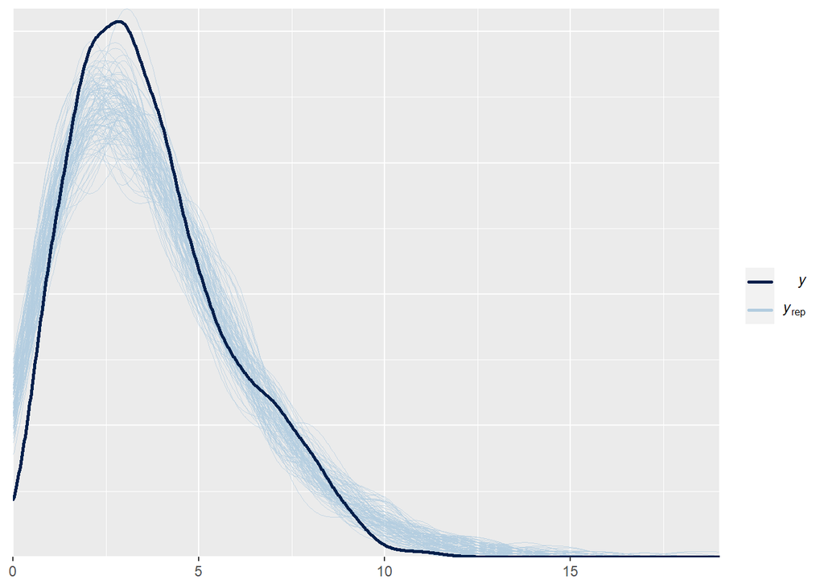

```r
sp.brm1f %>% pp_check(type = "dens_overlay", ndraws = 100)
```

####5 DHARMA residuals

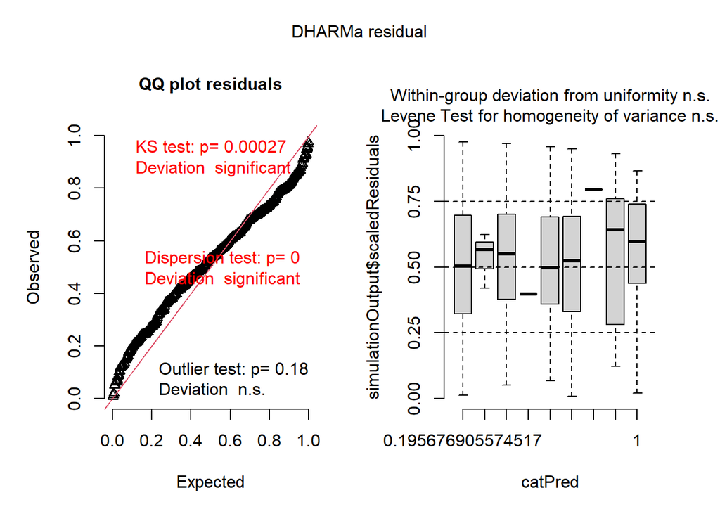

```r
preds <- sp.brm1f %>% posterior_predict(
  ndraws = 250,
  summary = FALSE
)
abnd.resids <- createDHARMa(
  simulatedResponse = t(preds),
  observedResponse = fish.sp.abnd$sp.richness,
  fittedPredictedResponse = apply(preds, 2, median),
  integerResponse = "TRUE"
)
plot(abnd.resids)
```

Showing underdispersion again, but this can be explained as for abundance (the routines for residual checking brms models don’t incorporate autocorrelation)

### 4.2.4 Model investigation

####1 Frequentist

```r
sp.glmmTMB.ac %>% summary()
```

```
 Family: poisson  ( log )
Formula:
sp.richness ~ (1 | plotID) + Treatment + (ar1(0 + factor(Date) |      plotID))
Data: fish.sp.abnd

     AIC      BIC   logLik deviance df.resid
  1672.8   1705.7   -828.4   1656.8      447

Random effects:

Conditional model:
 Groups   Name                   Variance  Std.Dev.  Corr
 plotID   (Intercept)            3.602e-08 0.0001898
 plotID.1 factor(Date)2022-11-25 5.444e-02 0.2333257 0.98 (ar1)
Number of obs: 450, groups:  plotID, 25

Conditional model:
            Estimate Std. Error z value Pr(>|z|)
(Intercept)   1.1806     0.1138  10.370  < 2e-16 ***
TreatmentBQ  -0.3226     0.1647  -1.959 0.050170 .
TreatmentDL  -0.3302     0.1648  -2.003 0.045148 *
TreatmentDM   0.3039     0.1580   1.924 0.054380 .
TreatmentW    0.5778     0.1560   3.704 0.000212 ***
---
Signif. codes:  0 '***' 0.001 '**' 0.01 '*' 0.05 '.' 0.1 ' ' 1
```

```r
sp.glmmTMB.ac %>% r.squaredGLMM()
```

```
Error in .nullFitRE.default(object, envir): object's call contains dotted names: 'glmmTMB(formula = sp.richness ~ (1 | plotID) + Treatment + (ar1(0 + ''    factor(Date) | plotID)), data = fish.sp.abnd, family = poisson(link = "log"), ''    ziformula = ~0, dispformula = ~1, REML = TRUE)'and cannot be…
```

```r
sp.glmmTMB2 %>% r.squaredGLMM()
```

```
                R2m       R2c
delta     0.2880667 0.3915695
lognormal 0.3094456 0.4206298
trigamma  0.2647075 0.3598172
```

Significant differences between intercept (BH) and DL, W.

0.98 ar1

The model without the ar term is explaining 36% of the variance in species richness with the RE, 26% without

####2 Bayesian

```r
sp.brm1f$fit %>% tidyMCMC(
  pars = wch,
  estimate.method = "median",
  conf.int = TRUE,
  conf.method = "HPDinterval",
  rhat = TRUE,
  ess = TRUE
)
```

```
# A tibble: 8 × 7
  term                 estimate std.error    conf.low conf.high  rhat   ess
  <chr>                   <dbl>     <dbl>       <dbl>     <dbl> <dbl> <int>
1 b_Intercept            1.17      0.117   0.929        1.39    1.00   2246
2 b_TreatmentBQ         -0.322     0.167  -0.645        0.00960 1.00   2391
3 b_TreatmentDL         -0.329     0.173  -0.637        0.0434  1.00   2249
4 b_TreatmentDM          0.314     0.164  -0.0300       0.631   1.00   2278
5 b_TreatmentW           0.587     0.159   0.291        0.915   1.00   2300
6 ar[1]                  0.159     0.544  -0.842        0.989   1.00   2606
7 sderr                  0.0234    0.0211  0.00000552   0.0690  0.999  2336
8 sd_plotID__Intercept   0.220     0.0523  0.136        0.340   1.00   2252
```

```r
sp.brm1f %>% brms::bayes_R2(
  re.form = NA,
  summary = FALSE
) %>%
  median_hdci()
```

```
          y      ymin      ymax .width .point .interval
1 0.4193943 0.2747103 0.5604343   0.95 median      hdci
```

```r
sp.brm1f %>% brms::bayes_R2(
  re.form = NULL,
  summary = FALSE
) %>%
  median_hdci()
```

```
          y      ymin      ymax .width .point .interval
1 0.5426008 0.4715026 0.6014015   0.95 median      hdci
```

I’m concerned about the estimate for ar - low estimate and very wide confidence intervals overlapping zero, not anywhere close to the frequentist estimate

Interestingly the model appears to explain more of the variance compared with the frequentist approach - 95% confidence that amount falls between between 47 and 60%.

```r
sp.brm1f %>%
  emmeans(~Treatment, type = "link") %>%
  pairs() %>%
  gather_emmeans_draws() %>%
  summarise(
    "P>" = sum(.value > 0) / n(),
    "P<" = sum(.value < 0) / n(),
  )
```

```
# A tibble: 10 × 3
   contrast   `P>`   `P<`
   <chr>     <dbl>  <dbl>
 1 BH - BQ  0.970  0.0304
 2 BH - DL  0.968  0.0321
 3 BH - DM  0.0292 0.971
 4 BH - W   0      1
 5 BQ - DL  0.506  0.494
 6 BQ - DM  0      1
 7 BQ - W   0      1
 8 DL - DM  0      1
 9 DL - W   0      1
10 DM - W   0.0433 0.957
```

Similarly to the abundance model, there is high (>95%) confidence in differences in all contrasts EXCEPT BQ-DL